# Prosper Loan Data Exploration by Yeqing Zhang

[output not shown]

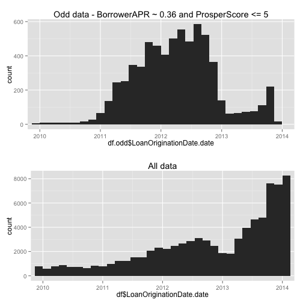

It appears that these loans are mainly within period of 2011-2013. Did something happen after the beginnig of 2013 which led to the reduction?

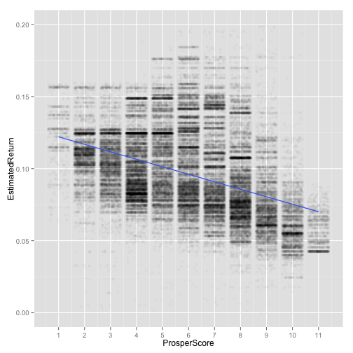

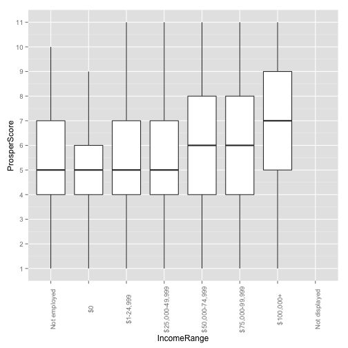

IncomeRange lower than or equal to $50K (including “Not employed”) get median value of ProsperScore 5. $50K-$100K gets 6 and over $100K gets 7.

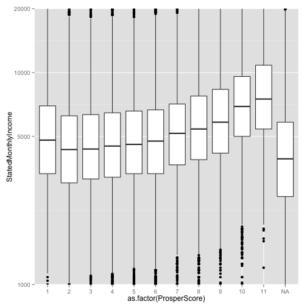

The boxplot shows that the median value of StatedMonthlyIncome tend to be higher with increase of the Prosper Score. Yet there is only one oddity: ProsperScore of 1 has higher income than Score 2 and even 5. This could be due to that some people lied about their income which led to a low credit ratings and thus a low ProsperScore. The median values of StatedMonthlyIncome against ProsperScore appears to be an exponential distribution.

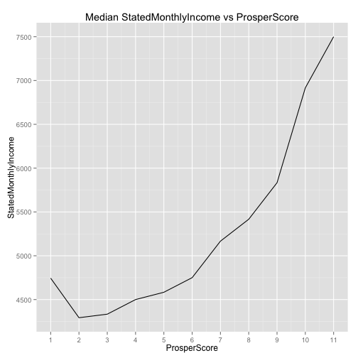

The above plot shows the median value of StatedMonthlyIncome presents an increasing trend against ProsperScore.

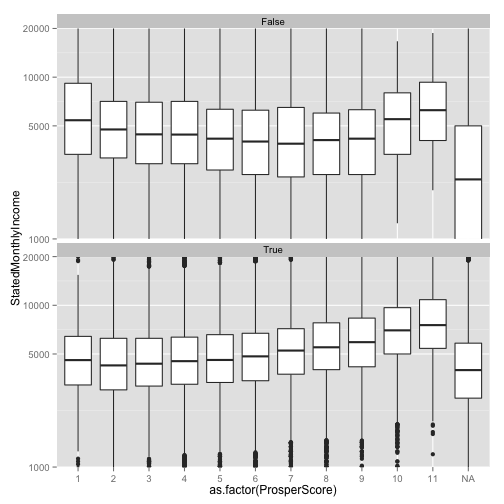

Above plot shows the same plot as the previous one but with split of IncomeVerifiable. It is noticed that the oddity of Prosper 1 still exists even in the IncomeVerifiable = TRUE subset. This means there are other factors that contribute to this oddity.

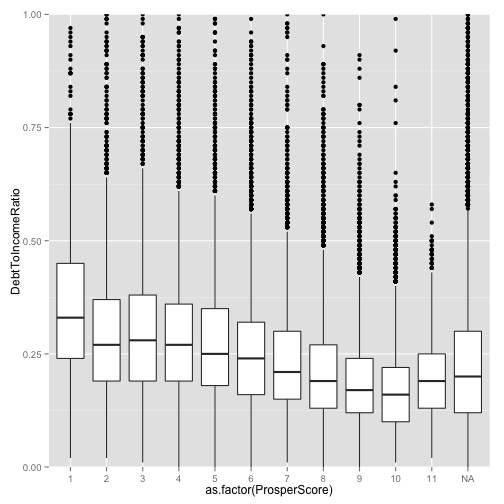

It makes sense that DebtToIncomeRatio is negatively correlated with ProsperScore.

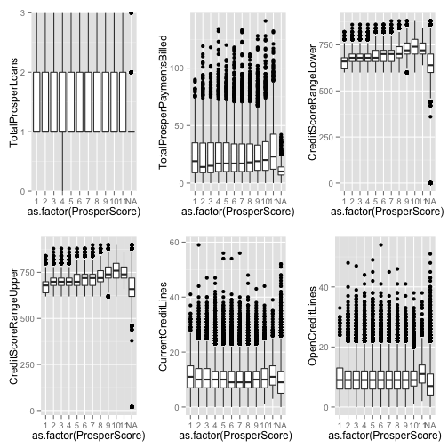

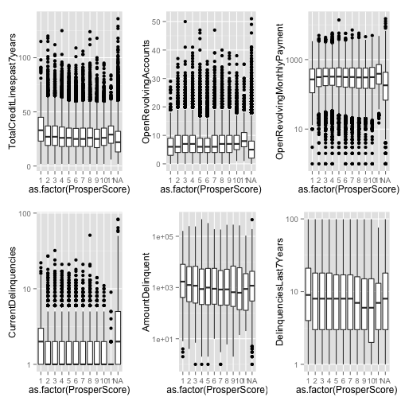

It seems that the TotalProsperPaymentsBills, CreditScoreRangeLower, CreditScoreRangeUpper are positively correlated with ProsperScore. AmountDelinquent, DelinquenciesLast7Years are negatively correlated with ProsperScore.

## LoanOriginalAmount

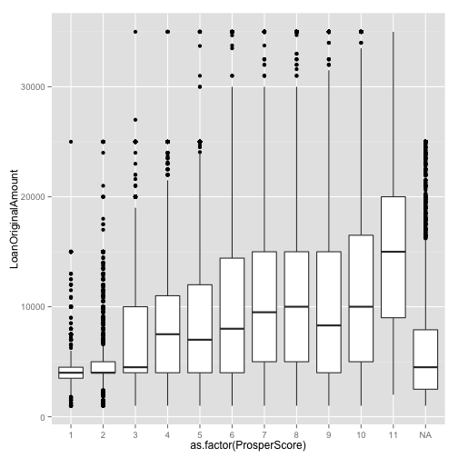

In general, the median values of LoanOriginalAmount shows that the LoanOriginalAmount increases with increase of ProsperScore. This makes sense as lenders could be cautious with lending larger amount with larger risks (i.e. low ProsperScore). The NA values for loans before 2009, which led to the question that why those loans have much lower LoanOriginalAmount with median value around 4000?

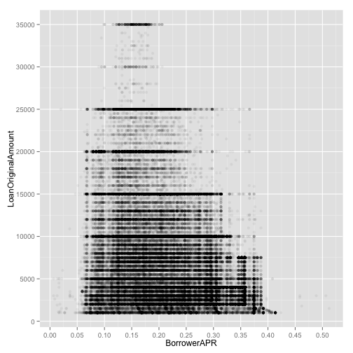

With the increase of LoanOriginalAmount, the width of BorrowerAPR is narrowing down from 0.05-0.40 for $1K to 0.10-0.20 at $35K.

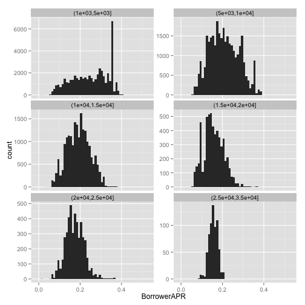

# Bivariate Analysis

### Talk about some of the relationships you observed in this part of the investigation. How did the feature(s) of interest vary with other features in the dataset?

As described in the Bivariate Plots Section, ProsperScore has strong negative correlation with BorrowerAPR, LenderYield, EstimatedEffectiveYield, EstimatedLoss, EstimatedReturn. ProsperScore has strong positive correlation with CreditScoreRangeLower and CreditScoreRangeUpper (these two are correlated with each other). It has some correlation with DebtToIncomeRatio (negative) and StatedMonthlyIncome (positive).

Also, as the LoanOriginalAmount increases, the BorrowerAPR is narrowing down, which means the options for larger loans are limited.

By investigating the distributions of BorrowerAPR by ProsperScore, it is found that there are quite a lot of loans with interest of 0.35797 and 0.35643 within ProsperScore range of 2-5. A further check shows that these loans are mainly created in 2011-2012.

### Did you observe any interesting relationships between the other features (not the main feature(s) of interest)?

CreditScoreRangeLower and CreditScoreRangeUpper are correlated with each other. BorrowerAPR and LenderYield are correlated to each other.

### What was the strongest relationship you found?

The ProsperScore is strongly correlated with interest-related variables, particularly BorrowerAPR. It has some correlation with CreditScoreRangeLower/CreditScoreRangeUpper, but this is lower than the one with BorrowerAPR, LenderYield, EstimatedEffectiveYield, EstimatedLoss, EstimatedReturn.

# Multivariate Plots Section

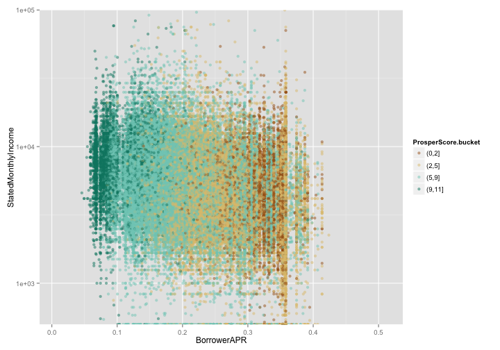

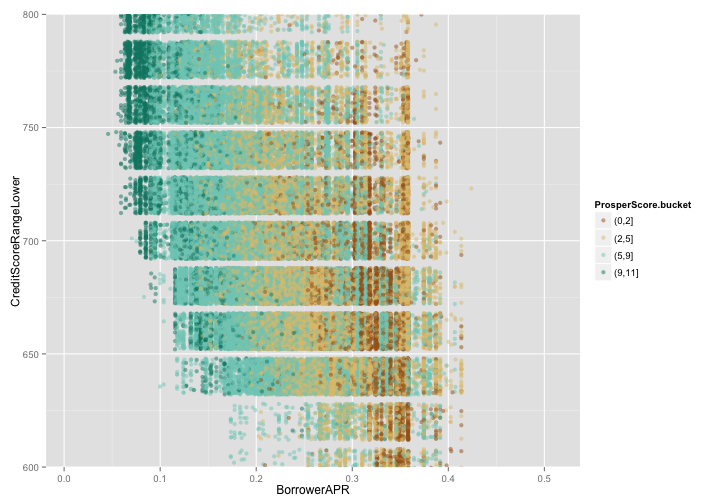

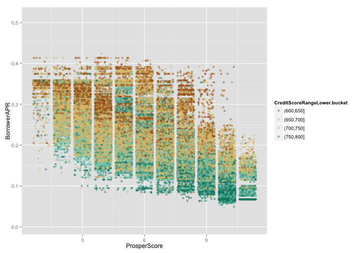

It seems that the CreditScoreRangeLower present a negative linear correlation (though a bit weak) with BorrowerAPR. Also, BorrowerAPR is within a smaller range with larger median values and more lower ProsperScore when the CreditScoreRangeLower is small.

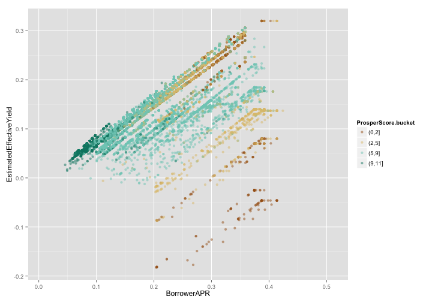

The distribution for BorrowerAPR and EstimatedEffectiveYield is clearly consisted of multiple straight lines. On the direction from top left to bottom right, the ProsperScore tends to be decreasing but seems to be bimodal or multimodal for lower range scores (1-5).

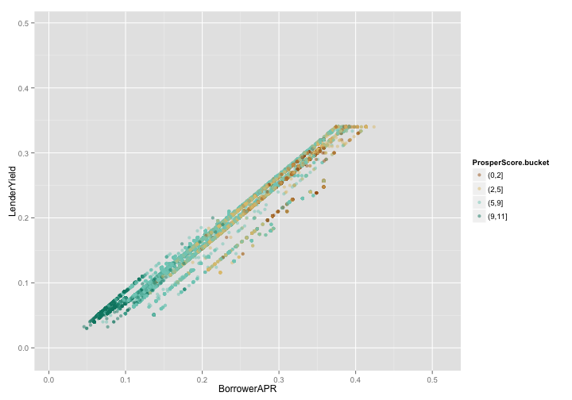

[output not shown]

[output not shown]

[output not shown]

```
##
##     0     1
## 64563 12994
```

```
##    ProsperScore ProsperScore.pred
## 1            NA                 7
## 2             7                 7
## 3            NA                NA
## 4             9                 8
## 5             4                 5
## 6            10                 7
## 7             2                 4
## 8             4                 5
## 9             9                 8
## 10           11                 8
## 11            7                 5
## 12           NA                 7
## 13            4                 6
## 14            8                 7
```

[output cut: 36 more lines]

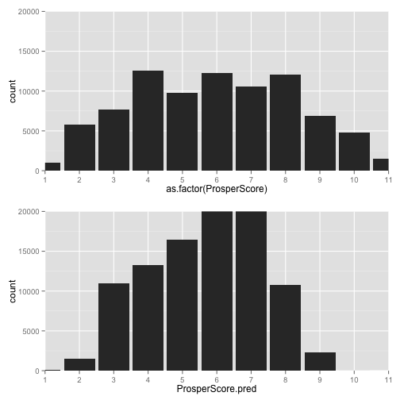

The results of the model seems to be quite bad as it only predicts 17% of the correct ProsperScore. It doesn't predict correctly for loans with ProsperScore over 9 and equal to 1.

# Multivariate Analysis

### Talk about some of the relationships you observed in this part of the investigation. Were there features that strengthened each other in terms of looking at your feature(s) of interest?

I plotted the StatedMonthlyIncome and BorrowerAPR split by ProsperScore but found the ProsperScore is a little crowded. So I split the ProsperScore into 4 buckets. The relationship confirmed that ProsperScore decreases with increase of BorrowerAPR, which means loans with lower risks have higher ProsperScore. But there is only a very weak negative correlation between StatedMonthlyIncome and BorrowerAPR. Another plot showing the relationship between CreditScoreRangeLower and BorrowerAPR presents BorrowerAPR tends to be higher with lower CreditScoreRangeLower and higher ProsperScore means higher Credit Score.

Also, by looking at the variables of BorrowerAPR, LenderYield, EstimatedEffectiveYield, EstimatedLoss, EstimatedReturn, I found BorrowerAPR and LenderYield are tightly correlated with pearson correlation neaer 1. It is also interesting to see that EstimatedEffectiveYield are always higher than EstimatedReturn. The EstimatedLoss and EstimatedEffectiveYield tend to be a linear relationship.

### Were there any interesting or surprising interactions between features?

It is interesting to see the income (StatedMonthlyIncome) doesn't impact the BorrowerAPR so much (though it has a very weak impact). This is probably that the income itself is not a strong indicator of high credit from the point view of Prosper.

### OPTIONAL: Did you create any models with your dataset? Discuss the strengths and limitations of your model.

Yes, I created a linear model with the dataset. The main strength of the model is that it highlights the what factors contribute to the ProsperScore. For example, for model m5, for every 0.05 increase of BorrowerAPR, the ProsperScore decreases by about 1 (=0.05 * -19.324). However, the R squared of this model is small (~0.464), which means another half of the variance is unexplained.

# Final Plots and Summary

### Plot One

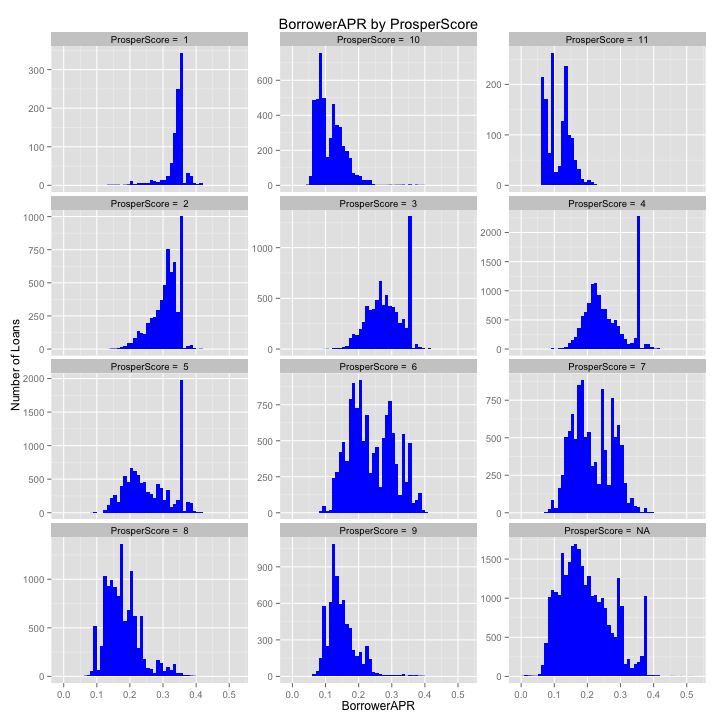

### Description One

The distribution of BorrowerAPR shifts from right to left with increase of ProsperScore, which indicates a negative correlation between ProsperScore and BorrowerAPR. It also shows there are a few peak values with BorrowerAPR near 0.36 for ProsperScore within 2-5.

### Plot Two

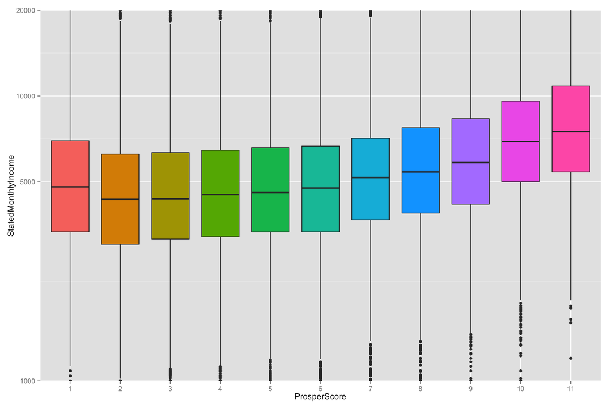

### Description Two

StatedMonthlyIncome tends to be higher with increase of the Prosper Score except for ProsperScore of 1 which has higher income than Score 2 and even 5.

### Plot Three

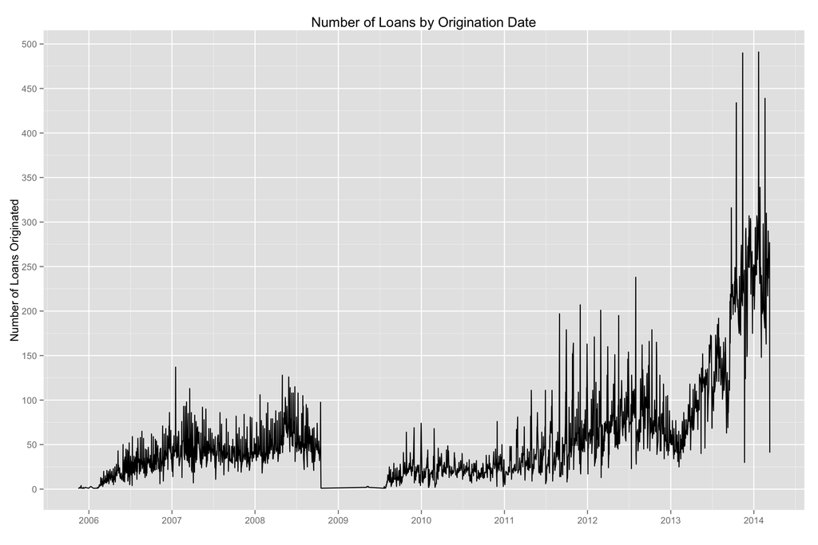

### Description Three

# Reflection

The biggest challenge for this project is the selection of variables. There are many variables (81) in this dataset and it is quite hard to decide which variables to begin with. Fortunately, following the example project, I was able to create a correlation matrix which eased the variable selection process. I soon realised the ProsperScore is highly correlated with interest related variables such as BorrowerAPR and LenderYield. Before performing any analyses, I did the data profiling including looking at the types and structure of data columns. After performing the univariate exploration, I was able to get a general idea of the distribution of each interesting variable and discovered that there are so many loans with BorrowAPR at around 0.36. I was also able to tell the stories from the financial crisis impact from the time series plot from LoanOriginationDate. In the Bivariate Plots Section, I confirmed the negative correlation between BorrowerAPR and ProsperScore by looking at the jittered scatterplot and boxplot. I still struggled to understand how the ProsperScore can be predicted from properly selected variables. Further effort could probably be focused on analysing the variable association with the ProsperScore quantatively in order to predict the score more accurately.